| title: “Land Use and Green/Open Spaces in Berlin” |
| --- |
| subtitle: “A descriptive analysis using QGIS and R” |
| author: “Finta Francis” |
| date: “29 October 2026” |
| output: |
| html_document: |
| toc: true |
| toc_depth: 3 |
| number_sections: true |
| theme: readable |

# 1. Introduction

Urban green and open spaces can include forests, parks, allotment gardens, meadows, and other vegetated areas. Understanding their distribution across urban districts is relevant to research on environmental conditions, urban planning, and potential inequalities in access to green environments.

This project uses land-use data from the Berlin Environmental Atlas to explore how recorded land-use areas are distributed across Berlin’s twelve administrative districts. QGIS was used for initial spatial data exploration, mapping, geometry validation, and investigation of overlapping areas. R was subsequently used for descriptive summaries, visualisations, and a sensitivity analysis based on alternative definitions of green/open space.

The project is an initial exploratory analysis. It does not directly measure residents’ access to green spaces, the quality of those spaces, or their effects on health.

## 1.1 Research questions

This project addresses five research questions:

1. **Data structure:** How are mapped land-use features distributed across Berlin districts and land-use categories?
2. **Recorded area:** Which land-use categories contribute the largest summed recorded areas, and how do their average recorded areas per feature differ?
3. **District comparisons:** Which districts have the largest and smallest recorded areas in selected green/open-space categories?
4. **Area coverage:** How do the summed recorded areas compare with the official administrative areas of Berlin’s districts?
5. **Sensitivity analysis:** How much do district-level green/open-space estimates change when additional land-use categories are included?

The fifth question is particularly important because the estimated area depends on how green/open space is defined.

# 2. Data source and preprocessing

## 2.1 Data source

The analysis uses the Berlin Environmental Atlas land-use and green/open-space inventory for 2021.

The original dataset was downloaded in GeoPackage format and imported into QGIS.

| Data characteristic | Description |
| --- | --- |
| Source | Berlin Environmental Atlas |
| Dataset | Land-use and green/open-space inventory, 2021 |
| Original layer | `b_gruen_und_freiflaechenbestand_2021` |
| File format | GeoPackage (`.gpkg`) |
| Coordinate reference system | EPSG:25833 — ETRS89 / UTM zone 33N |
| Number of spatial features | 26,397 |
| Area field | `flalle`, recorded area in square metres according to the dataset documentation |

The `flalle` field was used for the area summaries. The analysis assumes that its values are comparable across records, while recognising that a spot check of two features is not sufficient to verify every recorded area.

## 2.2 QGIS preprocessing workflow

The following steps were completed in QGIS before the summary data were analysed in R.

**Step 1 — Load and explore the spatial data.**

The original GeoPackage layer was loaded into QGIS. Its attribute table and relevant fields were inspected, including `schluessel`, `bezirk`, `enutzung`, and `flalle`.

**Step 2 — Create a thematic map.**

A thematic map was prepared to visualise land-use and green/open-space categories across Berlin. The map was exported as a PNG for project documentation.

**Step 3 — Check geometry validity.**

The QGIS Processing Toolbox’s *Check validity* algorithm returned:

- Valid features: 26,397
- Invalid features: 0
- Processing errors: 0

All features passed the selected geometry-validity check. This result concerns the validity of individual geometries; it does not establish that different polygons cannot overlap.

**Step 4 — Inspect recorded and calculated areas.**

The `flalle` field was compared with the QGIS-calculated geometry area for two sample features.

| Feature ID | Recorded `flalle` (m²) | Calculated geometry area (m²) |
| --- | --- | --- |
| 1992 | 2,244.310 | 2,244.278 |
| 1996 | 4,646.920 | 4,646.857 |

The values were closely aligned in these two examples. This was a spot check, not a validation of every feature.

**Step 5 — Investigate overlapping areas.**

An overlap investigation was carried out in QGIS, and an overlapping area was identified and removed. This was a corrective preprocessing step. The analysis should not be interpreted as proof that every possible overlap in the dataset has been eliminated unless the corrected, saved layer has been comprehensively checked.

**Step 6 — Prepare a summary table.**

QGIS was used to summarise `flalle` by district (`bezirk`) and land-use category (`enutzung`) using the *Statistics by categories* tool. The resulting summary was exported to CSV for analysis in R.

The CSV contains aggregated statistics rather than the original polygon geometries. Therefore, the R analysis describes the supplied summary data; it does not independently verify spatial overlaps or polygon boundaries.

## 2.3 Analytical approach

The analysis proceeds in stages:

1. Inspect missing values and duplicate district–category combinations.
2. Describe the number of mapped features by district and category.
3. Compare summed and average recorded areas by land-use category.
4. Explore selected green/open-space categories by district.
5. Compare summed recorded areas with official district areas.
6. Conduct a sensitivity analysis using narrow and broad category definitions.

Area values are converted from square metres to hectares where appropriate:

$$1\text{ hectare} = 10{,}000\text{ m}^2$$

# 3. Import and data-quality checks

## 3.1 Load the summary dataset

The CSV is imported as `land_use_summary`. Each row represents a district–category summary rather than an individual polygon.

```r
# Inspect the structure of the imported dataset
glimpse(land_use_summary)
```

```
## Rows: 255
## Columns: 16
## $ bezirk   <chr> "Mitte", "Mitte", "Mitte", "Mitte", "Steglitz-Zehlendorf", "T…
## $ enutzung <chr> "Body of water", "Housing area", "Public / special use", "Cor…
## $ count    <dbl> 80, 442, 204, 112, 1425, 39, 853, 1274, 718, 1365, 66, 28, 12…
## $ unique   <dbl> 80, 442, 204, 112, 1425, 39, 853, 1274, 718, 1364, 65, 28, 12…
## $ min      <dbl> 875.34, 673.80, 815.62, 633.10, 1213.99, 230.97, 1937.42, 247…
## $ max      <dbl> 79809.14, 97319.87, 876509.29, 50281.71, 223029.19, 39831.67,…
## $ range    <dbl> 78933.80, 96646.07, 875693.67, 49648.61, 221815.20, 39600.70,…
## $ sum      <dbl> 1361157.5, 8184928.2, 5590254.8, 1289882.3, 30885738.8, 28822…
## $ mean     <dbl> 17014.469, 18517.937, 27403.210, 11516.806, 21674.203, 7390.4…
## $ median   <dbl> 10084.950, 15487.980, 16133.350, 8410.545, 18572.590, 3982.34…
## $ stddev   <dbl> 17778.880, 12842.928, 65005.571, 9522.604, 14606.130, 8636.65…
## $ minority <dbl> 875.34, 673.80, 815.62, 633.10, 1213.99, 230.97, 1937.42, 247…
## $ majority <dbl> 875.34, 673.80, 815.62, 633.10, 1213.99, 230.97, 1937.42, 247…
## $ q1       <dbl> 4445.720, 9926.240, 9535.840, 4816.980, 11672.100, 1655.800, …
## $ q3       <dbl> 23389.35, 23765.40, 26643.37, 14644.08, 28130.51, 9845.60, 27…
## $ iqr      <dbl> 18943.635, 13839.160, 17107.525, 9827.105, 16458.410, 8189.80…
```

```r
# Check the district names
unique(land_use_summary$bezirk)
```

```
##  [1] "Mitte"                      "Steglitz-Zehlendorf"
##  [3] "Tempelhof-Schöneberg"       "Neukölln"
##  [5] "Marzahn-Hellersdorf"        "Lichtenberg"
##  [7] "Pankow"                     "Reinickendorf"
##  [9] "Charlottenburg-Wilmersdorf" "Spandau"
## [11] "Treptow-Köpenick"           "Friedrichshain-Kreuzberg"
```

## 3.2 Check missing values and duplicate combinations

Before conducting the descriptive analysis, we examine missing values and check whether a district–category combination appears more than once.

```r
# Check missing values in each column
colSums(is.na(land_use_summary))
```

```
##   bezirk enutzung    count   unique      min      max    range      sum
##        0        0        0        0        0        0        0        0
##     mean   median   stddev minority majority       q1       q3      iqr
##        0        0        0        0        0        0        0        0
```

```r
# Check whether district-category combinations are duplicated
land_use_summary |>
  count(bezirk, enutzung) |>
  filter(n > 1)
```

```
## # A tibble: 0 × 3
## # ℹ 3 variables: bezirk <chr>, enutzung <chr>, n <int>
```

No missing values or duplicate district–category combinations were reported in the supplied summary table.

These checks concern the summary CSV. They do not establish that the original spatial layer has no duplicate geometries, missing spatial features, or overlapping polygons.

# 4. Descriptive analysis of mapped land use

## 4.1 How many mapped features are recorded in each district?

The first analysis compares the number of mapped features represented in each district. The `count` field records the number of source features contributing to each district–category summary.

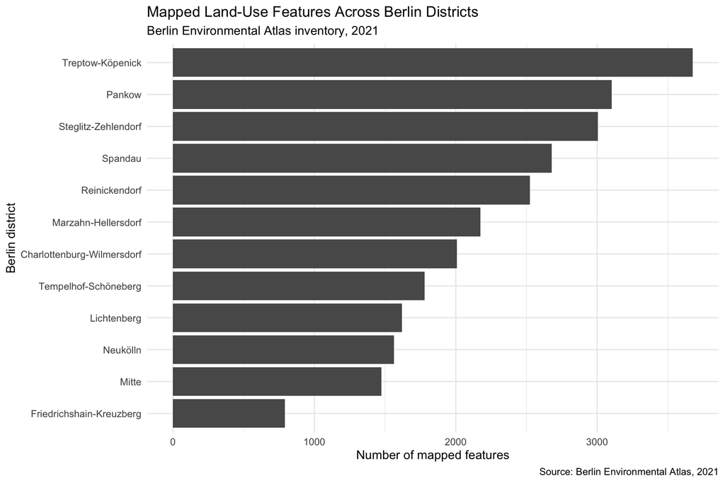

```r
district_features <- land_use_summary |>
  group_by(bezirk) |>
  summarise(
    total_features = sum(count, na.rm = TRUE),
    .groups = "drop"
  ) |>
  arrange(desc(total_features))

ggplot(
  district_features,
  aes(
    x = reorder(bezirk, total_features),
    y = total_features
  )
) +
  geom_col() +
  coord_flip() +
  labs(
    title = "Mapped Land-Use Features Across Berlin Districts",
    subtitle = "Berlin Environmental Atlas inventory, 2021",
    x = "Berlin district",
    y = "Number of mapped features",
    caption = "Source: Berlin Environmental Atlas, 2021"
  ) +
  theme_minimal()
```

### Interpretation

The chart describes how the number of mapped features varies across districts. A district with more features does not necessarily have a larger land area: the number of records depends on how the land has been divided into mapped features.

Feature counts should therefore be interpreted separately from the summed recorded area.

## 4.2 Which land-use categories have the most mapped features?

The next analysis compares the number of mapped features across land-use categories.

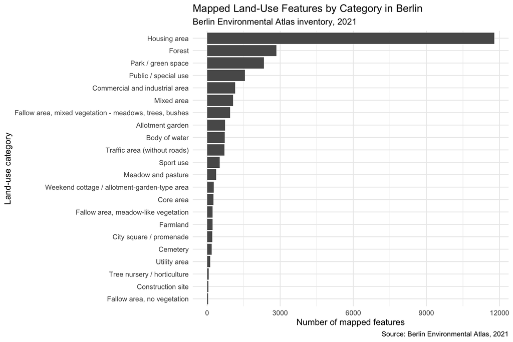

```r
category_features <- land_use_summary |>
  group_by(enutzung) |>
  summarise(
    total_features = sum(count, na.rm = TRUE),
    .groups = "drop"
  ) |>
  arrange(total_features)

ggplot(
  category_features,
  aes(
    x = reorder(enutzung, total_features),
    y = total_features
  )
) +
  geom_col() +
  coord_flip() +
  labs(
    title = "Mapped Land-Use Features by Category in Berlin",
    subtitle = "Berlin Environmental Atlas inventory, 2021",
    x = "Land-use category",
    y = "Number of mapped features",
    caption = "Source: Berlin Environmental Atlas, 2021"
  ) +
  theme_minimal()
```

### Interpretation

This chart identifies categories represented by many mapped features and those represented by fewer features. However, a high feature count does not necessarily imply a large total area. Many small features can collectively cover less land than a few large features.

## 4.3 Which categories have the largest summed recorded areas?

The `flalle` values are summed across districts for each land-use category. These values are presented as recorded areas, with the unit interpreted as square metres according to the dataset documentation.

```r
category_totals <- land_use_summary |>
  group_by(enutzung) |>
  summarise(
    total_features = sum(count, na.rm = TRUE),
    total_flalle = sum(sum, na.rm = TRUE),
    .groups = "drop"
  ) |>
  arrange(desc(total_flalle))

print(category_totals, n = Inf)
```

```
## # A tibble: 22 × 3
##    enutzung                                          total_features total_flalle
##    <chr>                                                      <dbl>        <dbl>
##  1 Housing area                                               11786   240670956.
##  2 Forest                                                      2848   160974511.
##  3 Park / green space                                          2335    59942942.
##  4 Body of water                                                729    54145436.
##  5 Commercial and industrial area                              1147    48517619.
##  6 Public / special use                                        1553    38247996.
##  7 Allotment garden                                             734    31140164.
##  8 Fallow area, mixed vegetation - meadows, trees, …            939    27888320.
##  9 Mixed area                                                  1065    22912320.
## 10 Farmland                                                     223    20408320.
## 11 Sport use                                                    519    18091190.
## 12 Meadow and pasture                                           365    15065797.
## 13 Traffic area (without roads)                                 713    12348438.
## 14 Cemetery                                                     192    11225565.
## 15 Weekend cottage / allotment-garden-type area                 268     8485012.
## 16 Fallow area, meadow-like vegetation                          224     7969326.
## 17 Utility area                                                 130     5606989.
## 18 Core area                                                    262     4072842.
## 19 Tree nursery / horticulture                                   61     2898201.
## 20 Fallow area, no vegetation                                    39     1195634.
## 21 City square / promenade                                      215     1108931.
## 22 Construction site                                             50      949622.
```

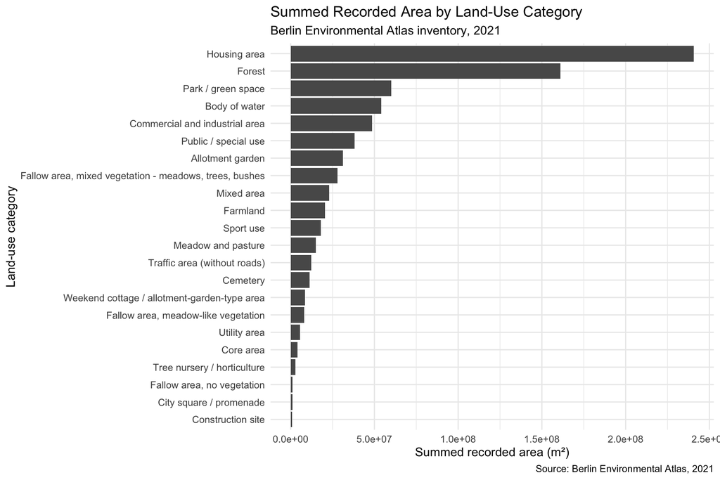

```r
ggplot(
  category_totals,
  aes(
    x = reorder(enutzung, total_flalle),
    y = total_flalle
  )
) +
  geom_col() +
  coord_flip() +
  labs(
    title = "Summed Recorded Area by Land-Use Category",
    subtitle = "Berlin Environmental Atlas inventory, 2021",
    x = "Land-use category",
    y = "Summed recorded area (m²)",
    caption = "Source: Berlin Environmental Atlas, 2021"
  ) +
  theme_minimal()
```

### Interpretation

Housing areas have the largest summed recorded area in the supplied summary, while forest also accounts for a substantial recorded area.

This comparison shows why both feature counts and area values are useful. A category can contain relatively few features but still have a large summed recorded area.

## 4.4 How does the average recorded area per feature differ by category?

To explore differences in the typical size of mapped features, the summed recorded area is divided by the number of contributing features.

```r
category_comparison <- land_use_summary |>
  group_by(enutzung) |>
  summarise(
    total_features = sum(count, na.rm = TRUE),
    total_flalle = sum(sum, na.rm = TRUE),
    mean_flalle_per_feature = total_flalle / total_features,
    .groups = "drop"
  ) |>
  arrange(desc(mean_flalle_per_feature))

print(category_comparison, n = Inf)
```

```
## # A tibble: 22 × 4
##    enutzung                   total_features total_flalle mean_flalle_per_feat…¹
##    <chr>                               <dbl>        <dbl>                  <dbl>
##  1 Farmland                              223    20408320.                 91517.
##  2 Body of water                         729    54145436.                 74274.
##  3 Cemetery                              192    11225565.                 58466.
##  4 Forest                               2848   160974511.                 56522.
##  5 Tree nursery / horticultu…             61     2898201.                 47511.
##  6 Utility area                          130     5606989.                 43131.
##  7 Allotment garden                      734    31140164.                 42425.
##  8 Commercial and industrial…           1147    48517619.                 42300.
##  9 Meadow and pasture                    365    15065797.                 41276.
## 10 Fallow area, meadow-like …            224     7969326.                 35577.
## 11 Sport use                             519    18091190.                 34858.
## 12 Weekend cottage / allotme…            268     8485012.                 31660.
## 13 Fallow area, no vegetation             39     1195634.                 30657.
## 14 Fallow area, mixed vegeta…            939    27888320.                 29700.
## 15 Park / green space                   2335    59942942.                 25671.
## 16 Public / special use                 1553    38247996.                 24628.
## 17 Mixed area                           1065    22912320.                 21514.
## 18 Housing area                        11786   240670956.                 20420.
## 19 Construction site                      50      949622.                 18992.
## 20 Traffic area (without roa…            713    12348438.                 17319.
## 21 Core area                             262     4072842.                 15545.
## 22 City square / promenade               215     1108931.                  5158.
## # ℹ abbreviated name: ¹mean_flalle_per_feature
```

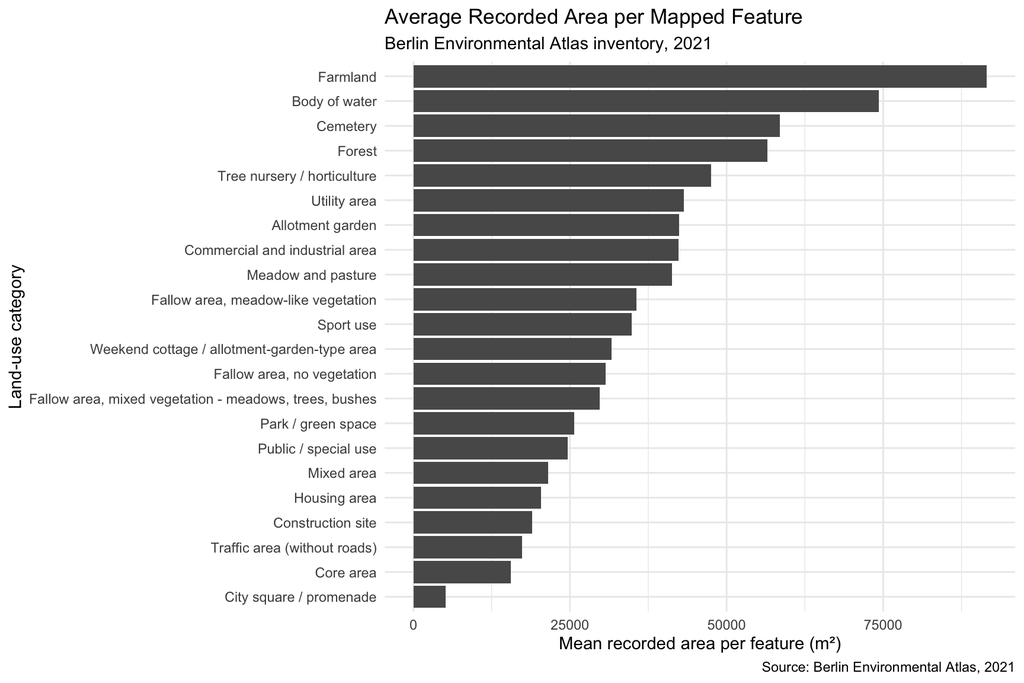

```r
ggplot(
  category_comparison,
  aes(
    x = reorder(enutzung, mean_flalle_per_feature),
    y = mean_flalle_per_feature
  )
) +
  geom_col() +
  coord_flip() +
  labs(
    title = "Average Recorded Area per Mapped Feature",
    subtitle = "Berlin Environmental Atlas inventory, 2021",
    x = "Land-use category",
    y = "Mean recorded area per feature (m²)",
    caption = "Source: Berlin Environmental Atlas, 2021"
  ) +
  theme_minimal()
```

### Interpretation

The average recorded area per feature helps distinguish categories that consist of many relatively small mapped features from those with fewer, larger features.

The descriptive results indicate that housing areas contribute many mapped features, whereas farmland has a high average recorded area per feature. Forest also has a substantially larger average recorded area per feature than housing.

These averages are calculated from aggregated counts and area values. They do not describe the full distribution of individual polygon sizes, and they can be influenced by unusually large features.

## 4.5 What percentage of the total summed recorded area does each category contribute?

The following calculation estimates each category’s percentage contribution to the total of the recorded `flalle` values in the supplied summary table.

```r
category_shares <- category_comparison |>
  mutate(
    share_percent =
      100 * total_flalle / sum(total_flalle, na.rm = TRUE)
  ) |>
  arrange(desc(share_percent))

print(
  category_shares |>
    select(enutzung, total_flalle, share_percent),
  n = Inf
)
```

```
## # A tibble: 22 × 3
##    enutzung                                           total_flalle share_percent
##    <chr>                                                     <dbl>         <dbl>
##  1 Housing area                                         240670956.        30.3
##  2 Forest                                               160974511.        20.3
##  3 Park / green space                                    59942942.         7.55
##  4 Body of water                                         54145436.         6.82
##  5 Commercial and industrial area                        48517619.         6.11
##  6 Public / special use                                  38247996.         4.82
##  7 Allotment garden                                      31140164.         3.92
##  8 Fallow area, mixed vegetation - meadows, trees, b…    27888320.         3.51
##  9 Mixed area                                            22912320.         2.89
## 10 Farmland                                              20408320.         2.57
## 11 Sport use                                             18091190.         2.28
## 12 Meadow and pasture                                    15065797.         1.90
## 13 Traffic area (without roads)                          12348438.         1.56
## 14 Cemetery                                              11225565.         1.41
## 15 Weekend cottage / allotment-garden-type area           8485012.         1.07
## 16 Fallow area, meadow-like vegetation                    7969326.         1.00
## 17 Utility area                                           5606989.         0.706
## 18 Core area                                              4072842.         0.513
## 19 Tree nursery / horticulture                            2898201.         0.365
## 20 Fallow area, no vegetation                             1195634.         0.151
## 21 City square / promenade                                1108931.         0.140
## 22 Construction site                                       949622.         0.120
```

### Interpretation

Three results stand out in the current summary:

- **Housing area — approximately 30.3%:** the largest contribution to the summed recorded area.
- **Forest — approximately 20.3%:** the second-largest contribution.
- **Park / green space — approximately 7.55%:** a distinct land-use category, not a comprehensive measure of all green environments.

The 7.55% figure must not be interpreted as the percentage of Berlin that is green. Forests, allotment gardens, meadows, fallow areas and other categories may also represent vegetated environments.

These percentages describe the composition of the summed recorded values in the supplied dataset, rather than independently verified proportions of Berlin’s total land area.

# 5. Recorded land-use area in hectares

## 5.1 Convert recorded area to hectares

For easier interpretation, the recorded area is converted from square metres to hectares. The conversion is applied to the summary values, and the resulting values are used in the subsequent area comparisons.

```r
# Convert square metres to hectares
land_use_summary <- land_use_summary |>
  mutate(
    total_hectares = sum / 10000
  )

# Display the largest land-use categories by recorded area
land_use_summary |>
  group_by(enutzung) |>
  summarise(
    total_hectares = sum(total_hectares, na.rm = TRUE),
    .groups = "drop"
  ) |>
  arrange(desc(total_hectares))
```

```
## # A tibble: 22 × 2
##    enutzung                                               total_hectares
##    <chr>                                                           <dbl>
##  1 Housing area                                                   24067.
##  2 Forest                                                         16097.
##  3 Park / green space                                              5994.
##  4 Body of water                                                   5415.
##  5 Commercial and industrial area                                  4852.
##  6 Public / special use                                            3825.
##  7 Allotment garden                                                3114.
##  8 Fallow area, mixed vegetation - meadows, trees, bushes          2789.
##  9 Mixed area                                                      2291.
## 10 Farmland                                                        2041.
## # ℹ 12 more rows
```

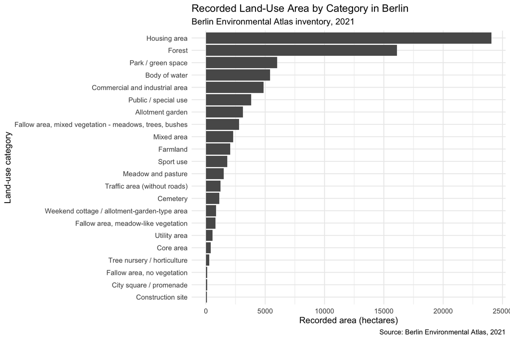

```r
category_area <- land_use_summary |>
  group_by(enutzung) |>
  summarise(
    total_hectares = sum(sum, na.rm = TRUE) / 10000,
    .groups = "drop"
  ) |>
  arrange(desc(total_hectares))

ggplot(
  category_area,
  aes(
    x = reorder(enutzung, total_hectares),
    y = total_hectares
  )
) +
  geom_col() +
  coord_flip() +
  labs(
    title = "Recorded Land-Use Area by Category in Berlin",
    subtitle = "Berlin Environmental Atlas inventory, 2021",
    x = "Land-use category",
    y = "Recorded area (hectares)",
    caption = "Source: Berlin Environmental Atlas, 2021"
  ) +
  theme_minimal()
```

### Interpretation

Forest occupies substantially more recorded area than the category specifically labelled *Park / green space*. This highlights the importance of the land-use classification when studying urban green environments.

The chart alone does not establish what percentage of Berlin is green, whether the city has sufficient green space, or whether residents can access it easily. Those questions require additional information and, for spatial coverage estimates, appropriate validation of the mapped area.

# 6. District-level analysis of green/open space

## 6.1 Define the selected green/open-space categories

For the first district-level analysis, seven land-use categories are selected as an operational definition of green/open space.

```r
green_categories <- c(
  "Forest",
  "Park / green space",
  "Allotment garden",
  "Meadow and pasture",
  "Fallow area, meadow-like vegetation",
  "Fallow area, mixed vegetation - meadows, trees, bushes",
  "Tree nursery / horticulture"
)

green_by_district <- land_use_summary |>
  filter(enutzung %in% green_categories) |>
  group_by(bezirk) |>
  summarise(
    green_hectares = sum(sum, na.rm = TRUE) / 10000,
    .groups = "drop"
  ) |>
  arrange(desc(green_hectares))

print(green_by_district)
```

```
## # A tibble: 12 × 2
##    bezirk                     green_hectares
##    <chr>                               <dbl>
##  1 Treptow-Köpenick                    8764.
##  2 Steglitz-Zehlendorf                 3631.
##  3 Pankow                              3436.
##  4 Spandau                             3313.
##  5 Reinickendorf                       3243.
##  6 Charlottenburg-Wilmersdorf          2554.
##  7 Lichtenberg                         1488.
##  8 Marzahn-Hellersdorf                 1417.
##  9 Tempelhof-Schöneberg                 995.
## 10 Neukölln                             900.
## 11 Mitte                                641.
## 12 Friedrichshain-Kreuzberg             207.
```

This definition includes selected categories that represent vegetation or green/open land. It is an analytical choice for this project, rather than an official or exhaustive definition of green space.

Water bodies are kept separate as blue space. Other categories, such as cemeteries and city squares, are considered in the broader definition used in the sensitivity analysis.

## 6.2 Which districts have the largest and smallest recorded areas in the selected categories?

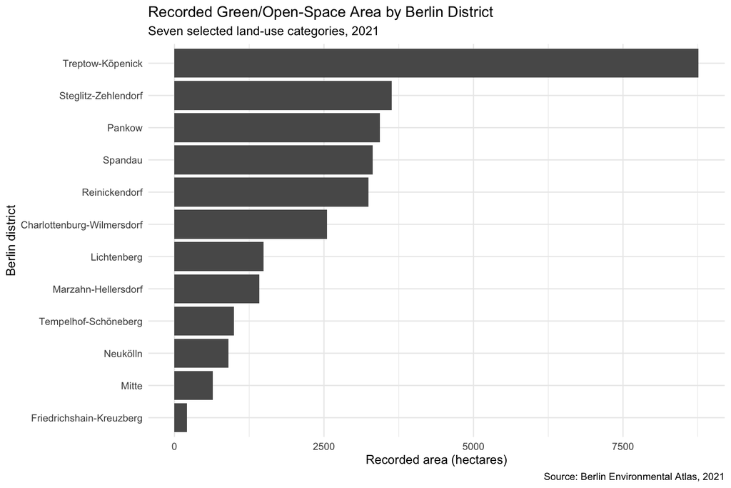

```r
ggplot(
  green_by_district,
  aes(
    x = reorder(bezirk, green_hectares),
    y = green_hectares
  )
) +
  geom_col() +
  coord_flip() +
  labs(
    title = "Recorded Green/Open-Space Area by Berlin District",
    subtitle = "Seven selected land-use categories, 2021",
    x = "Berlin district",
    y = "Recorded area (hectares)",
    caption = "Source: Berlin Environmental Atlas, 2021"
  ) +
  theme_minimal()
```

### Interpretation

The initial results show that:

- **Treptow-Köpenick** has the largest recorded area in the selected categories, at approximately 8,764 hectares.
- **Friedrichshain-Kreuzberg** has the smallest, at approximately 207 hectares.
- **Mitte** also has a relatively small recorded area, at approximately 641 hectares.

These are comparisons of absolute recorded area. They do not necessarily indicate which district has the highest proportion of its land area classified as green/open space. Differences in district size must also be considered.

## 6.3 How do total recorded areas compare with official district areas?

Before calculating a proportion, it is useful to compare the sum of all recorded land-use categories with the official administrative area of each district.

```r
land_use_summary |>
  group_by(bezirk) |>
  summarise(
    total_recorded_hectares = sum(sum, na.rm = TRUE) / 10000,
    .groups = "drop"
  ) |>
  arrange(desc(total_recorded_hectares))
```

```
## # A tibble: 12 × 2
##    bezirk                     total_recorded_hectares
##    <chr>                                        <dbl>
##  1 Treptow-Köpenick                            15650.
##  2 Pankow                                       9264.
##  3 Steglitz-Zehlendorf                          9229.
##  4 Spandau                                      8481.
##  5 Reinickendorf                                8141.
##  6 Charlottenburg-Wilmersdorf                   5541.
##  7 Marzahn-Hellersdorf                          5285.
##  8 Lichtenberg                                  4598.
##  9 Tempelhof-Schöneberg                         4524.
## 10 Neukölln                                     3888.
## 11 Mitte                                        3170.
## 12 Friedrichshain-Kreuzberg                     1615.
```

The following district areas are used for an exploratory comparison. They are rounded values and should be checked against the relevant official Statistics Berlin-Brandenburg publication before the results are used as formal estimates.

```r
district_areas <- tibble::tribble(
  ~bezirk, ~district_hectares,
  "Mitte", 3940,
  "Friedrichshain-Kreuzberg", 2040,
  "Pankow", 10322,
  "Charlottenburg-Wilmersdorf", 6469,
  "Spandau", 9188,
  "Steglitz-Zehlendorf", 10256,
  "Tempelhof-Schöneberg", 5305,
  "Neukölln", 4493,
  "Treptow-Köpenick", 16773,
  "Marzahn-Hellersdorf", 6182,
  "Lichtenberg", 5212,
  "Reinickendorf", 8932
)

area_check <- land_use_summary |>
  group_by(bezirk) |>
  summarise(
    total_recorded_hectares = sum(sum, na.rm = TRUE) / 10000,
    .groups = "drop"
  ) |>
  left_join(district_areas, by = "bezirk") |>
  mutate(
    difference_hectares =
      district_hectares - total_recorded_hectares
  )

print(area_check)
```

```
## # A tibble: 12 × 4
##    bezirk           total_recorded_hecta…¹ district_hectares difference_hectares
##    <chr>                             <dbl>             <dbl>               <dbl>
##  1 Charlottenburg-…                  5541.              6469                928.
##  2 Friedrichshain-…                  1615.              2040                425.
##  3 Lichtenberg                       4598.              5212                614.
##  4 Marzahn-Hellers…                  5285.              6182                897.
##  5 Mitte                             3170.              3940                770.
##  6 Neukölln                          3888.              4493                605.
##  7 Pankow                            9264.             10322               1058.
##  8 Reinickendorf                     8141.              8932                791.
##  9 Spandau                           8481.              9188                707.
## 10 Steglitz-Zehlen…                  9229.             10256               1027.
## 11 Tempelhof-Schön…                  4524.              5305                781.
## 12 Treptow-Köpenick                 15650.             16773               1123.
## # ℹ abbreviated name: ¹total_recorded_hectares
```

### Interpretation

The summed recorded areas are lower than the corresponding administrative areas in this comparison.

This difference does not, by itself, prove that the dataset is incorrect. Possible explanations include the scope of the inventory, classification rules, excluded areas, or differences between the mapped land-use inventory and the administrative area figures.

The comparison is a diagnostic check. It does not establish why the differences occur.

## 6.4 What proportion of each district’s area is represented by the summed recorded area?

The next calculation expresses the total recorded area as a percentage of the administrative area.

```r
area_check <- area_check |>
  mutate(
    recorded_area_share = 100 *
      total_recorded_hectares / district_hectares
  ) |>
  arrange(desc(recorded_area_share))

print(area_check)
```

```
## # A tibble: 12 × 5
##    bezirk           total_recorded_hecta…¹ district_hectares difference_hectares
##    <chr>                             <dbl>             <dbl>               <dbl>
##  1 Treptow-Köpenick                 15650.             16773               1123.
##  2 Spandau                           8481.              9188                707.
##  3 Reinickendorf                     8141.              8932                791.
##  4 Steglitz-Zehlen…                  9229.             10256               1027.
##  5 Pankow                            9264.             10322               1058.
##  6 Lichtenberg                       4598.              5212                614.
##  7 Neukölln                          3888.              4493                605.
##  8 Charlottenburg-…                  5541.              6469                928.
##  9 Marzahn-Hellers…                  5285.              6182                897.
## 10 Tempelhof-Schön…                  4524.              5305                781.
## 11 Mitte                             3170.              3940                770.
## 12 Friedrichshain-…                  1615.              2040                425.
## # ℹ abbreviated name: ¹total_recorded_hectares
## # ℹ 1 more variable: recorded_area_share <dbl>
```

The resulting percentage is the proportion represented by the **summed recorded area** relative to the supplied district-area figure. It should not automatically be interpreted as the proportion of the district covered by unique land.

In particular, this calculation is not a direct estimate of green-space coverage because the numerator includes all land-use categories. It is also sensitive to the completeness of the inventory and whether overlapping areas have been comprehensively resolved.

## 6.5 Reconfirm district totals

For transparency, the district totals can also be displayed in square metres and hectares.

```r
district_totals <- land_use_summary |>
  group_by(bezirk) |>
  summarise(
    total_recorded_m2 = sum(sum, na.rm = TRUE),
    total_recorded_ha = total_recorded_m2 / 10000,
    .groups = "drop"
  ) |>
  arrange(desc(total_recorded_ha))

print(district_totals)
```

```
## # A tibble: 12 × 3
##    bezirk                     total_recorded_m2 total_recorded_ha
##    <chr>                                  <dbl>             <dbl>
##  1 Treptow-Köpenick                  156503979.            15650.
##  2 Pankow                             92636399.             9264.
##  3 Steglitz-Zehlendorf                92291055.             9229.
##  4 Spandau                            84811871.             8481.
##  5 Reinickendorf                      81405192.             8141.
##  6 Charlottenburg-Wilmersdorf         55412113.             5541.
##  7 Marzahn-Hellersdorf                52851310.             5285.
##  8 Lichtenberg                        45984726.             4598.
##  9 Tempelhof-Schöneberg               45241930.             4524.
## 10 Neukölln                           38877998.             3888.
## 11 Mitte                              31703114.             3170.
## 12 Friedrichshain-Kreuzberg           16146441.             1615.
```

This is a second presentation of the same underlying recorded-area values, not an independent spatial validation.

# 7. Sensitivity analysis: alternative definitions of green/open space

## 7.1 Why conduct a sensitivity analysis?

There is no single category list in this exploratory project that automatically captures every possible form of green/open space. The result may depend on whether categories such as cemeteries, city squares, promenades, and weekend cottage/allotment-garden-type areas are included.

A sensitivity analysis addresses this issue by comparing two operational definitions while keeping the underlying dataset and district groupings unchanged.

- **Narrow definition:** the seven selected categories listed in Section 6.1.
- **Broad definition:** the same seven categories, plus cemeteries, city squares/promenades, and weekend cottage/allotment-garden-type areas.

This comparison assesses the effect of changing the category inclusion rules. It does not measure change over time.

## 7.2 Calculate the broader estimate

```r
broad_green_categories <- c(
  green_categories,
  "Cemetery",
  "City square / promenade",
  "Weekend cottage / allotment-garden-type area"
)

broad_green_by_district <- land_use_summary |>
  filter(enutzung %in% broad_green_categories) |>
  group_by(bezirk) |>
  summarise(
    broad_green_hectares = sum(sum, na.rm = TRUE) / 10000,
    .groups = "drop"
  )
```

## 7.3 Compare narrow and broad definitions

For each district, we calculate:

- The area under the narrow definition.
- The area under the broad definition.
- The absolute difference in hectares.
- The percentage increase relative to the narrow definition.

The percentage increase is calculated as:

$$\text{Percentage increase} =
\frac{\text{Broad area} - \text{Narrow area}}
{\text{Narrow area}} \times 100$$

```r
sensitivity_results <- green_by_district |>
  left_join(broad_green_by_district, by = "bezirk") |>
  mutate(
    absolute_change_ha = broad_green_hectares - green_hectares,
    percentage_change = 100 *
      absolute_change_ha / green_hectares
  ) |>
  select(
    bezirk,
    green_hectares,
    broad_green_hectares,
    absolute_change_ha,
    percentage_change
  ) |>
  arrange(desc(percentage_change))

print(sensitivity_results, n = Inf)
```

```
## # A tibble: 12 × 5
##    bezirk                 green_hectares broad_green_hectares absolute_change_ha
##    <chr>                           <dbl>                <dbl>              <dbl>
##  1 Friedrichshain-Kreuzb…           207.                 264.               57.1
##  2 Mitte                            641.                 769.              128.
##  3 Pankow                          3436.                4006.              570.
##  4 Neukölln                         900.                1040.              140.
##  5 Tempelhof-Schöneberg             995.                1125.              130.
##  6 Spandau                         3313.                3556.              244.
##  7 Reinickendorf                   3243.                3469.              226.
##  8 Lichtenberg                     1488.                1576.               87.6
##  9 Marzahn-Hellersdorf             1417.                1485.               67.4
## 10 Charlottenburg-Wilmer…          2554.                2663.              109.
## 11 Steglitz-Zehlendorf             3631.                3778.              147.
## 12 Treptow-Köpenick                8764.                8940.              176.
## # ℹ 1 more variable: percentage_change <dbl>
```

## 7.4 Visualise the relative increase

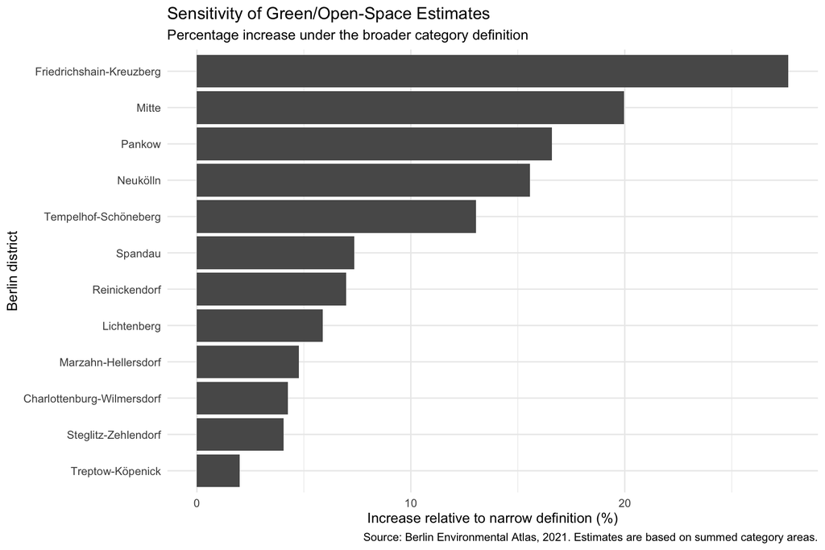

```r
ggplot(
  sensitivity_results,
  aes(
    x = reorder(bezirk, percentage_change),
    y = percentage_change
  )
) +
  geom_col() +
  coord_flip() +
  labs(
    title = "Sensitivity of Green/Open-Space Estimates",
    subtitle = "Percentage increase under the broader category definition",
    x = "Berlin district",
    y = "Increase relative to narrow definition (%)",
    caption = paste(
      "Source: Berlin Environmental Atlas, 2021.",
      "Estimates are based on summed category areas."
    )
  ) +
  theme_minimal()
```

## 7.5 Interpretation of the sensitivity analysis

The sensitivity analysis shows that the summed area estimates vary across Berlin districts according to which land-use categories are included. Adding cemeteries, city squares and promenades, and weekend cottage/allotment-garden-type areas increased the estimates in all twelve districts.

The relative increase ranged from approximately **2.0% in Treptow-Köpenick** to **27.6% in Friedrichshain-Kreuzberg**. Pankow showed the largest absolute increase, at approximately **570 hectares**, whereas Friedrichshain-Kreuzberg showed an increase of approximately **57 hectares**.

These results illustrate why absolute and relative changes should be considered together. A district can show a relatively small absolute increase but a substantial percentage increase when its narrow-definition estimate is small.

The findings indicate that the estimated area is sensitive to category selection. However, these are differences in summed recorded areas, not verified changes in unique green-space coverage. They should be interpreted alongside the dataset’s classification rules, spatial overlap checks, and coverage limitations.

# 8. Overall findings

This exploratory project used QGIS and R to describe land-use patterns and examine how selected green/open-space estimates vary across Berlin’s districts.

The main findings are:

1. **Mapped features vary across categories and districts.** Feature counts and recorded areas provide different information: a category with many mapped features does not necessarily occupy the largest area.
2. **Housing and forest account for substantial recorded areas.** In the supplied summary, housing has the largest contribution to the summed recorded area, while forest contributes more than the category specifically labelled Park / green space.
3. **Absolute green/open-space estimates vary by district.** Treptow-Köpenick has the largest recorded area under the narrow category definition, while Friedrichshain-Kreuzberg has the smallest.
4. **Recorded area is not the same as verified district coverage.** Summed recorded areas are lower than the administrative areas used for comparison. The differences require further investigation and do not, on their own, identify the cause.
5. **Category selection affects the results.** Including additional land-use categories increases the estimates in every district, with different absolute and relative increases.

# 9. Limitations and next steps

## 9.1 Limitations

Several limitations should be considered when interpreting the results.

- **Operational category definitions:** The narrow and broad lists are analytical choices for this project, not official or exhaustive measures of green space.
- **Geometry validation:** All 26,397 features passed the selected QGIS validity check, but geometry validity does not establish the absence of overlaps.
- **Overlap correction:** An overlapping area was investigated and removed in QGIS. The summary CSV does not independently establish that all possible overlaps were resolved in the final saved spatial layer.
- **Area-field verification:** The `flalle` and calculated geometry areas were closely aligned for two sample features only. This does not verify the entire dataset.
- **Administrative coverage:** The summed recorded areas do not equal the supplied official district areas. The reason for the differences has not been established.
- **Aggregated data:** The CSV contains district–category summaries rather than the original polygons. Spatial relationships cannot be fully re-evaluated from this file alone.
- **No population denominator:** Absolute hectares do not account for the number of residents in each district.
- **No accessibility analysis:** The project does not assess walking distance, public transport access, barriers, quality, or distribution of green spaces within districts.
- **Single-year analysis:** The inventory describes 2021. The sensitivity analysis compares definitions, not changes between years.

## 9.2 Suggested next steps

Further work could improve the validity and usefulness of the analysis:

1. Verify the final saved GeoPackage after the overlap correction and document the exact overlap-checking method and output.
2. Confirm the `flalle` field definition and compare recorded area with calculated polygon area across a larger sample or the full dataset.
3. Investigate the differences between summed recorded areas and official district areas using the original spatial layer and appropriate administrative boundaries.
4. Obtain verified district population data to explore green/open-space area per resident.
5. If suitable spatial and population data are available, investigate proximity or accessibility to green spaces rather than relying only on district-level totals.
6. For a temporal analysis, obtain comparable land-use data from additional years and assess whether classification and measurement methods are consistent.

# 10. Conclusion

This project provides an initial, reproducible descriptive workflow for exploring Berlin’s 2021 land-use inventory using QGIS and R. It combines spatial data exploration, geometry validation, area summaries, visualisation, district-level comparisons, and a sensitivity analysis of alternative green/open-space definitions.

The analysis highlights the importance of defining green/open space explicitly and distinguishing summed recorded area from verified spatial coverage. The results are useful as an exploratory starting point, but stronger conclusions about actual coverage, population-level availability, or accessibility require further spatial validation and additional data.

## Data source and documentation

**Berlin Environmental Atlas:** Land-use and green/open-space inventory, 2021.

**Dataset documentation:** [Data format description for land use from 2021 onwards](https://gdi.berlin.de/data/ua_flaechennutzung/docs/datenformatbeschreibung_Flaechennutzung_ab_2021.pdf).

**Project methods:** QGIS preprocessing and mapping, followed by descriptive and sensitivity analyses in R.